# Componentes principales

En realidad lo que queremos es máximixar la varianza de la proyección, si norma de ${\phi}$ = 1, un vector
$$\max{[\frac{1}{m}}(X^T\phi)^2]$$

Con la restricción que
$$\phi^t\phi=1$$

Ojo que lo que está adentro de la máximización es igual a::
$$(X^t \phi)^2 = (\phi^tX) *(X^t\phi)$$

Ya separando, lo que queremos máximizar es:
$$\phi^t *[\frac{1}{m} * \sum{XX^t}] * \phi$$

Resulta que lo que está en el corchete es la matriz de covarianza, por lo tanto nuestra optimización queda como.

$$\max{[\phi^t \sum \phi}]$$
sujeto a:

$$\phi^t\phi = 1$$
Esto se puede resolver con lagrangianos. Ojo que la matriz de covarianza está hecha para columnas, si se quiere para renglones es invertir la multiplicación.

El objetivo de componentes principales es *ortogonaizar* nuestros datos y lo hace asumiento relación líneal de los mismos, Por ejemplo:

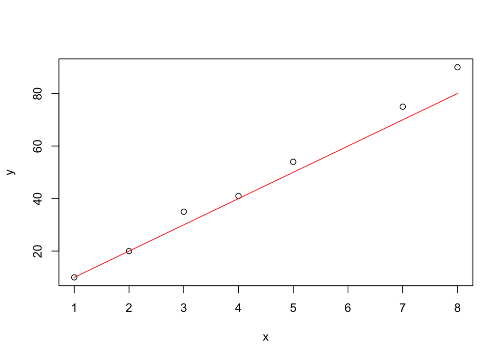

```r
x <- c(1,2,3,5,4,7, 8)
y <- c(10,20,35,54,41,75, 90)
plot(x,y)
lines(x, c(10,20,30,50,40,70, 80), col="red")
```

Estas dos variables tienen la misma información … a lo mejor podríamos hacer una sola que capte la relación línal de las mismas. Justamente esta es la intuición detrás de componentes principales.

# Implementación de ejemplo

Tenemos un dataset con el tipo de cambio de muchos paises (en dolares) el objetivo es reducir la dimension.

Ojo que es buena idea usar rendimientos, utilizaremos el rendimiento como el logaritmo de las diferencias sustentado en un teorema que dice que: si el rendimiento es pequeño el rendimiento es igual logaritmo de las diferencias.

Primero que nada limpiamos los datos

```r
library(corrplot)
setwd("~/maestria/metodos_multivariados")
tipo_cambio <- read.csv("tipo_cambio.csv")
date <-tipo_cambio$Date
tipo_cambio$Date <- NULL
tipo_cambio$Nicaragua <- NULL
df <- data.frame(1:491)
for(i in 1:ncol(tipo_cambio)){
   rendimientos <- diff(log(tipo_cambio[,i]))
   df[,i] <- (rendimientos - mean(rendimientos)) / sd(rendimientos)

}
names(df) <- names(tipo_cambio)
```

Separaremos cada uno de los archivos por contientes.

## America

Empezamos viendo la matriz de correlaciones:

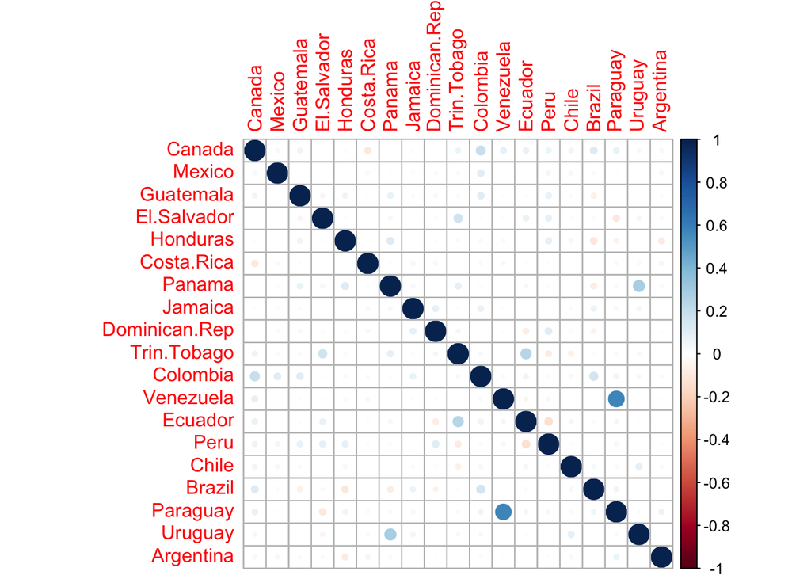

```r
# America
america <- names(df)[1:19]
america_df <- df[,which(america %in% america)]

corrplot(cor(america_df))
```

Realizamos su descomposición singular y hacemos un scatter plot de la proyeccion ortogonal de la primera componente vs la seguda y primera vs tercera:

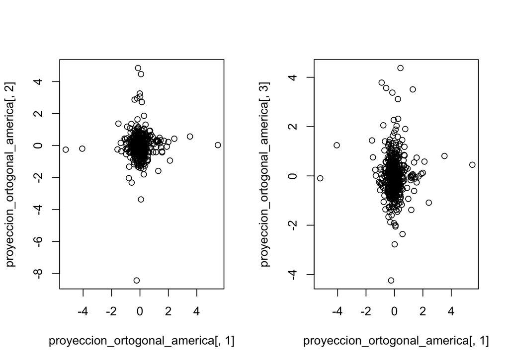

```r
sigma_america <- cov(america_df)
eigen_aux_america <- eigen(solve(sigma_america))
eigenvalores_america <- eigen_aux_america$values
eigenvectores_america <- eigen_aux_america$vectors
X_america <- as.matrix(america_df)
proyeccion_ortogonal_america <- X_america %*% eigenvectores_america


par(mfrow=c(1,2))
plot(proyeccion_ortogonal_america[,1], proyeccion_ortogonal_america[,2])
plot(proyeccion_ortogonal_america[,1], proyeccion_ortogonal_america[,3])
```

```r
eigenvalores_america / sum(eigenvalores_america)
```

```
##  [1] 0.11684219 0.07265558 0.07140628 0.06587261 0.05968773 0.05828227
##  [7] 0.05496328 0.05341886 0.04957587 0.04938687 0.04759971 0.04524364
## [13] 0.04330685 0.04290200 0.03828712 0.03585780 0.03429806 0.03215514
## [19] 0.02825816
```

Para efectos ilustrativos vamos a utilizar la función *princomp* apra plotearlo con *biplot*:

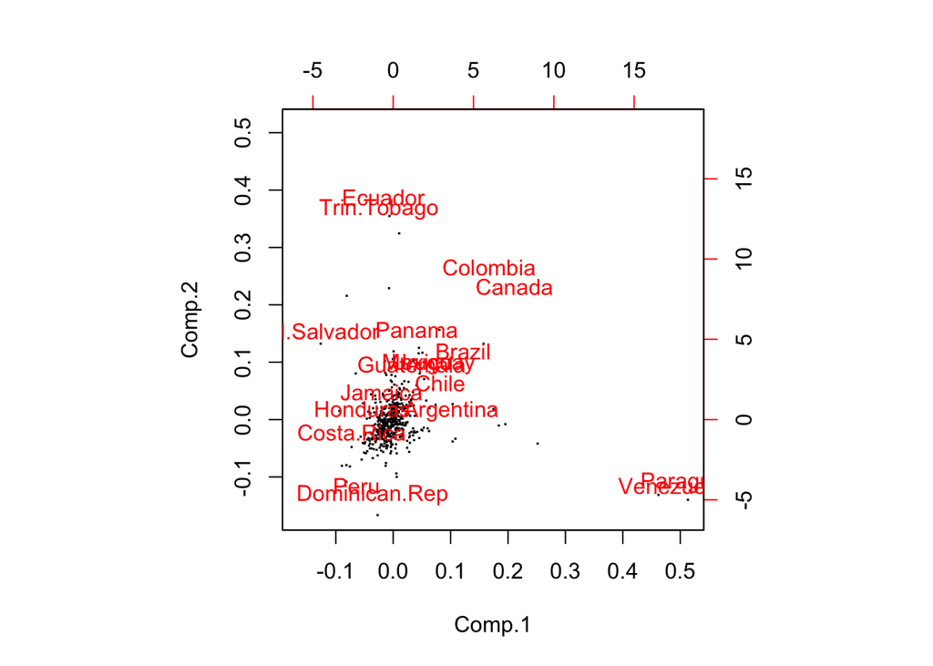

```r
biplot(princomp(america_df), var.axes = FALSE, cex=1, xlabs = rep(".", nrow(america_df)))
```

*Replicaremos este mismo código para los demás continentes*

# Europa

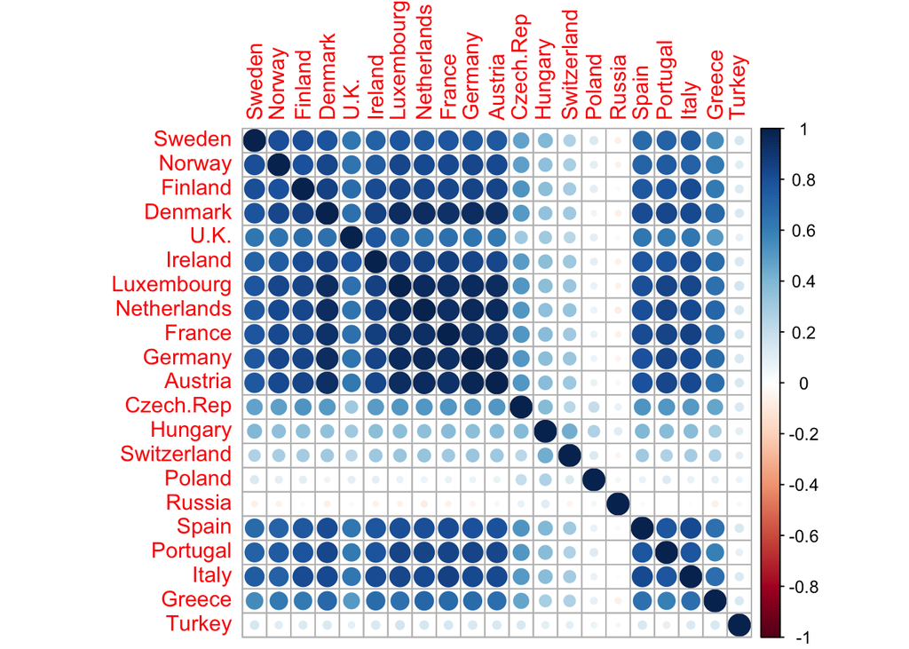

Realizamos su descomposición singular y hacemos un scatter plot de la proyeccion ortogonal de la primera componente vs la seguda y primera vs tercera:

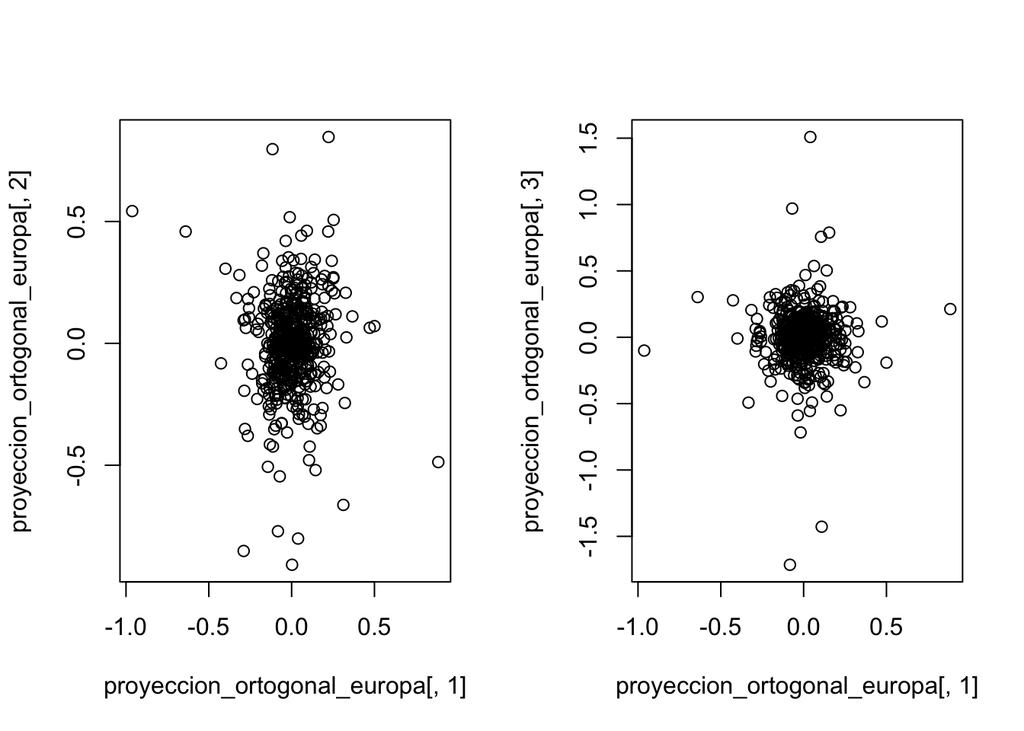

Varianza explicada por las componentes:

```
##  [1] 0.2995979646 0.1462386955 0.1218561036 0.0864840611 0.0806430025
##  [6] 0.0451584786 0.0373251296 0.0345441389 0.0271936611 0.0253778899
## [11] 0.0179723151 0.0150690906 0.0123050884 0.0103001347 0.0100183620
## [16] 0.0080407731 0.0063464395 0.0057396786 0.0054417036 0.0039126674
## [21] 0.0004346215
```

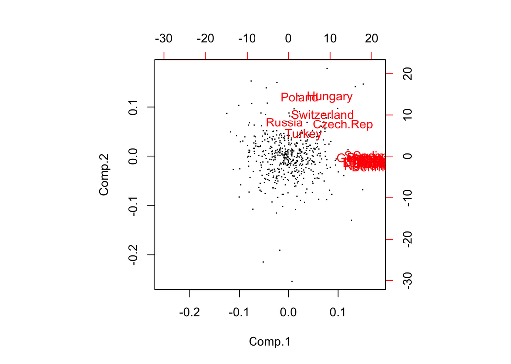

```r
biplot(princomp(europa_df), var.axes = FALSE, cex=1, xlabs = rep(".", nrow(america_df)))
```

# Asia

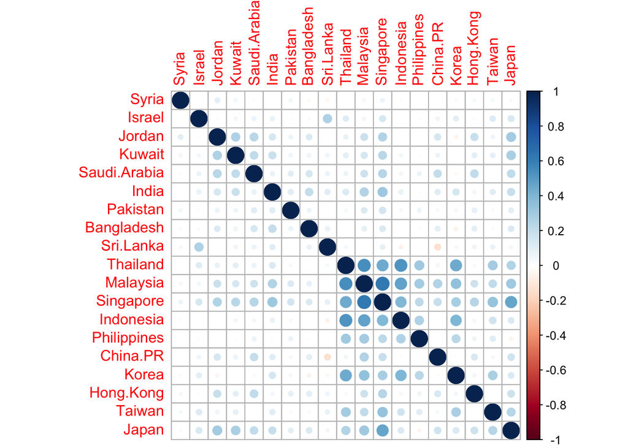

Realizamos su descomposición singular y hacemos un scatter plot de la proyeccion ortogonal de la primera componente vs la seguda y primera vs tercera:

[output not shown]

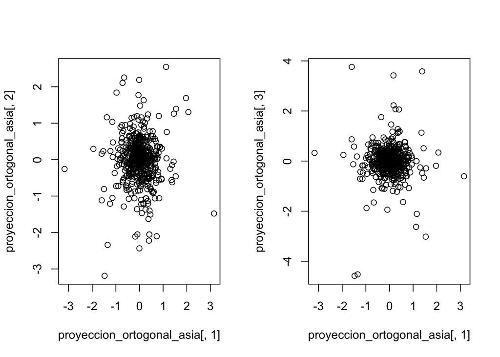

Varianza explicada por las componentes:

```
##  [1] 0.12591576 0.09167847 0.08771477 0.07206703 0.06499450 0.05900246
##  [7] 0.05518907 0.05337659 0.05157422 0.04677124 0.04416589 0.04211175
## [13] 0.03958139 0.03754043 0.03591662 0.03427247 0.02833073 0.01944900
## [19] 0.01034763
```

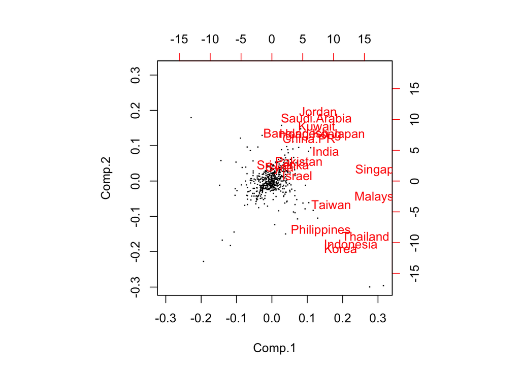

```r
biplot(princomp(asia_df), var.axes = FALSE, cex=1, xlabs = rep(".", nrow(america_df)))
```

# Africa

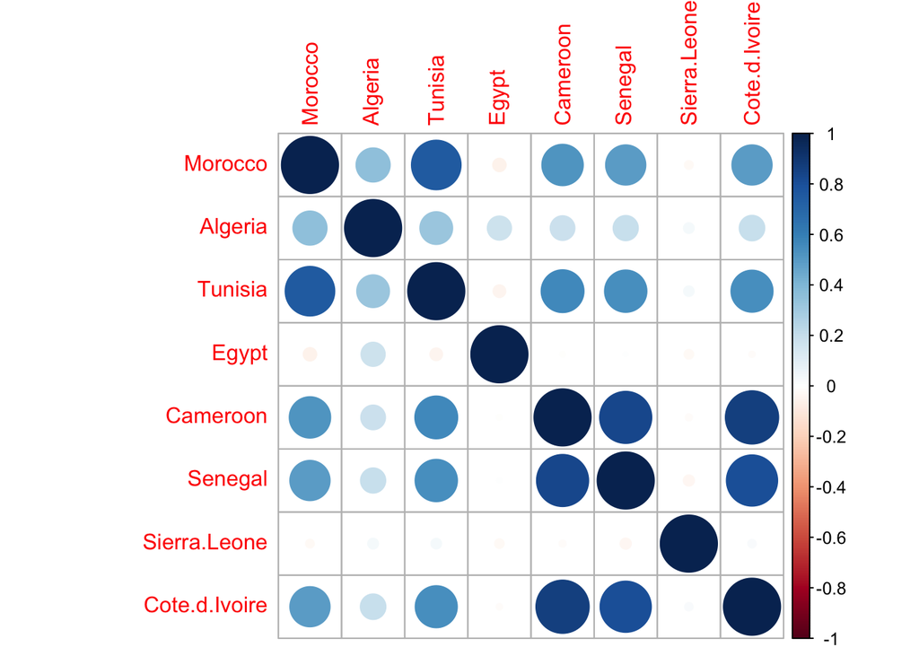

Realizamos su descomposición singular y hacemos un scatter plot de la proyeccion ortogonal de la primera componente vs la seguda y primera vs tercera:

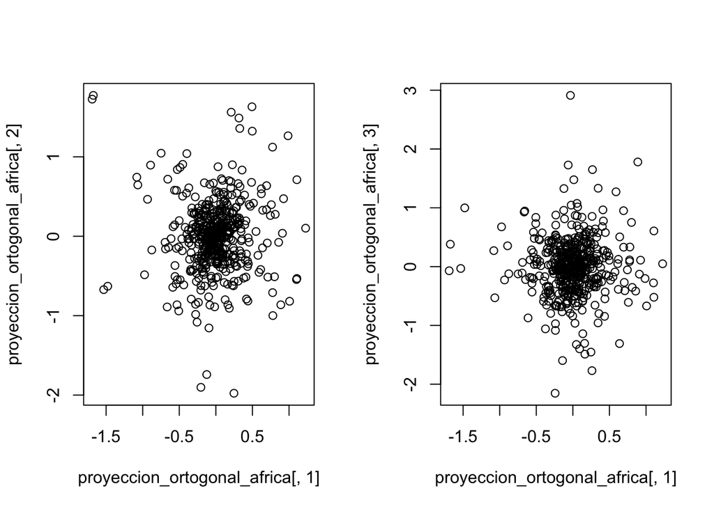

Varianza explicada por las componentes:

```
## [1] 0.36302389 0.22894863 0.18781312 0.07655344 0.04793909 0.04420872
## [7] 0.03919739 0.01231571
```

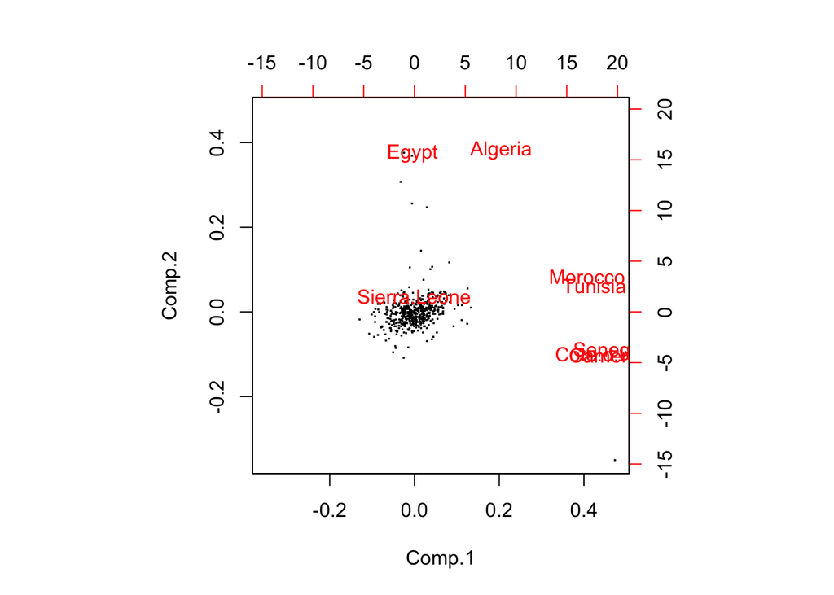

# Truco de Kernel

Un clasificador líneal (o proyección) es un producto punto.
$$K(x_i, x_j) = x_i * x_j = x_{i}^t x_{j}$$

Supongamos que el Kernel es en realidad un producto punto y este geometricamente hablando es la proyección de un vector sobre otro, esta proyección es alta si los vectores son parecidos… se puede decir que el producto punto *es una medida de simularidad*.

Si mapeo un punto de mis datos a otro espacio dimensional más grande:
$$\phi:x ---> \phi(x)$$

Al final un producto punto en ese nuevo espacio es:
$$K(x_{i}, x_{j}) = \phi(x_i)^t\phi(x_j)$$
Si en realidad el producto punto es una medida de similaridad, el resultado de este truco lo es también pero *en otro espacio*

Entonces, ¿que pasa si en lugar de usar la similaridad de la matriz de covarianza usamos un Kernel?.

Osea:
$$\max{[\phi^t (X^T X) \phi}] ---> \max{[\phi^t K(X) \phi}]$$

Este nuevo espacio dimensional se le conoce como espacio de *hilbert*.

# Implementación de Kernel PCA

Probaremos con el kernel gaussiano, donde la similaridad entre 2 vevtores está definida como, este viene por default donde h es: $1e^-4$:

*Kernel gaussiano*
$$K(X_1,X_2) = exp(\frac{||X_1 - X_2||^2}{h})$$

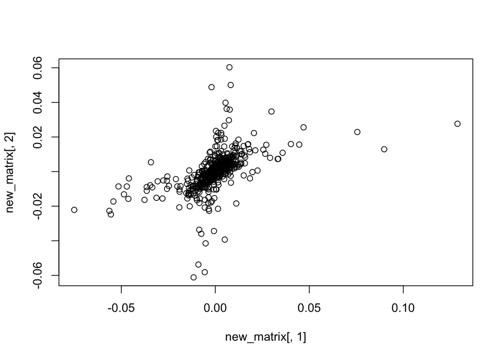

```r
library(kernlab)
kernel_new <- kpca(africa_df)
# The original data projected (rotated) on the principal components
new_matrix <- europa_df * kernel_new@eig

plot(new_matrix[,1], new_matrix[,2])
```

Y ahora esta es la varianza explicada por cada componente del kernel pca.

```r
kernel_new@eig / sum(kernel_new@eig)
```

```
##     Comp.1     Comp.2     Comp.3     Comp.4     Comp.5     Comp.6
## 0.39628576 0.13252260 0.11117056 0.10186517 0.09533597 0.09196687
##     Comp.7
## 0.07085307
```

Ojo que esta no es la misma que solamente con PCA y la grafica de las primeras doss compoonentes tiene una forma rara con *outliers*.